# Bank Marketing Campaign Prediction

The main objective of my project is to design a model that will be able to predict whether a customer will respond to the marketing campaign based on his/her information. I will predict the responded target variable based on all the input variables provided.

The flow of the project and my findings:

1. Understanding the dataset
2. Data Visualization
3. Data preprocessing/cleaning
4. Evaluate ML Algorithms - Building models
5. Performance comparison and choosing the best model
6. Model Tuning to Improve Result (If any)
7. Creating pkl file using pickling
8. Final conclusion

## 1. Understanding the dataset

The first part of my project is all about exploring the data. It includes the understanding the features of dataset and installing,importing required libraries.

### 1.1 Importing libraries and loading data

```python
import pandas as pd
import numpy as np
import seaborn as sns
from pandas.plotting import scatter_matrix
import matplotlib.pyplot as plt
from time import time
from IPython.display import display
from sklearn import model_selection
from sklearn.metrics import accuracy_score
from sklearn.metrics import classification_report
from sklearn.metrics import confusion_matrix
from sklearn.metrics import f1_score

%matplotlib inline

# Load the dataset
file = 'bank.csv'
full_data = pd.read_csv(file)
```

```python
# method for installing packages (if needed)
! pip install xgboost
```

```
You are using pip version 10.0.1, however version 20.2.3 is available.
```

### 1.2 More Info about dataset

```python
# Print the first few entries of the given dataset
display(full_data.head())
```

|  | age | job | marital | education | default | housing | loan | contact | month | day_of_week | ... | campaign | pdays | previous | poutcome | emp.var.rate | cons.price.idx | cons.conf.idx | euribor3m | nr.employed | y |
| --- | --- | --- | --- | --- | --- | --- | --- | --- | --- | --- | --- | --- | --- | --- | --- | --- | --- | --- | --- | --- | --- |
| 0 | 56 | housemaid | married | basic.4y | no | no | no | telephone | may | mon | ... | 1 | 999 | 0 | nonexistent | 1.1 | 93.994 | -36.4 | 4.857 | 5191.0 | no |
| 1 | 57 | services | married | high.school | unknown | no | no | telephone | may | mon | ... | 1 | 999 | 0 | nonexistent | 1.1 | 93.994 | -36.4 | 4.857 | 5191.0 | no |
| 2 | 37 | services | married | high.school | no | yes | no | telephone | may | mon | ... | 1 | 999 | 0 | nonexistent | 1.1 | 93.994 | -36.4 | 4.857 | 5191.0 | no |
| 3 | 40 | admin. | married | basic.6y | no | no | no | telephone | may | mon | ... | 1 | 999 | 0 | nonexistent | 1.1 | 93.994 | -36.4 | 4.857 | 5191.0 | no |
| 4 | 56 | services | married | high.school | no | no | yes | telephone | may | mon | ... | 1 | 999 | 0 | nonexistent | 1.1 | 93.994 | -36.4 | 4.857 | 5191.0 | no |

5 rows × 21 columns

```python
#about columns
full_data.info()
```

```
<class 'pandas.core.frame.DataFrame'>
RangeIndex: 41188 entries, 0 to 41187
Data columns (total 21 columns):
age               41188 non-null int64
job               41188 non-null object
marital           41188 non-null object
education         41188 non-null object
default           41188 non-null object
housing           41188 non-null object
loan              41188 non-null object
contact           41188 non-null object
month             41188 non-null object
day_of_week       41188 non-null object
duration          41188 non-null int64
campaign          41188 non-null int64
pdays             41188 non-null int64
previous          41188 non-null int64
poutcome          41188 non-null object
emp.var.rate      41188 non-null float64
cons.price.idx    41188 non-null float64
cons.conf.idx     41188 non-null float64
euribor3m         41188 non-null float64
nr.employed       7763 non-null float64
y                 41188 non-null object
dtypes: float64(5), int64(5), object(11)
memory usage: 6.6+ MB
```

```python
#dimensions of dataset
print("The dataset has",full_data.shape[1],"columns and", full_data.shape[0],"rows")
```

```
The dataset has 21 columns and 41188 rows
```

```python
#columns/features
full_data.columns
```

```
Index(['age', 'job', 'marital', 'education', 'default', 'housing', 'loan',
       'contact', 'month', 'day_of_week', 'duration', 'campaign', 'pdays',
       'previous', 'poutcome', 'emp.var.rate', 'cons.price.idx',
       'cons.conf.idx', 'euribor3m', 'nr.employed', 'y'],
      dtype='object')
```

### 1.3 Overview of responses and overall response rate

```python
# Calculate number of customers
n_customers = len(full_data)

# Calculate number of features
n_features = len(full_data.columns[:-1])     # 20 Feature cols and 1 target col

# Calculate reponded customers
n_subscribed = len(full_data[full_data['y'] == 'yes'])

# Calculate not responded customers
n_not_subscribed = len(full_data[full_data['y'] == 'no'])

# Calculate response rate
response_rate = n_subscribed/(n_customers)*100

# Print the results
print("Total number of customers: {}".format(n_customers))
print("Number of features: {}".format(n_features),"(and 1 target variable)")
print("Number of customers who subscribed: {}".format(n_subscribed))
print("Number of customers who did not subscribe: {}".format(n_not_subscribed))
print("Response rate of customers: {:.2f}%".format(response_rate))
```

```
Total number of customers: 41188
Number of features: 20 (and 1 target variable)
Number of customers who subscribed: 4640
Number of customers who did not subscribe: 36548
Response rate of customers: 11.27%
```

### 1.4 Statistical Summary of data

```python
display(full_data.describe())
```

|  | age | duration | campaign | pdays | previous | emp.var.rate | cons.price.idx | cons.conf.idx | euribor3m | nr.employed |
| --- | --- | --- | --- | --- | --- | --- | --- | --- | --- | --- |
| count | 41188.00000 | 41188.000000 | 41188.000000 | 41188.000000 | 41188.000000 | 41188.000000 | 41188.000000 | 41188.000000 | 41188.000000 | 7763.0 |
| mean | 40.02406 | 258.285010 | 2.567593 | 962.475454 | 0.172963 | 0.081886 | 93.575664 | -40.502600 | 3.621291 | 5191.0 |
| std | 10.42125 | 259.279249 | 2.770014 | 186.910907 | 0.494901 | 1.570960 | 0.578840 | 4.628198 | 1.734447 | 0.0 |
| min | 17.00000 | 0.000000 | 1.000000 | 0.000000 | 0.000000 | -3.400000 | 92.201000 | -50.800000 | 0.634000 | 5191.0 |
| 25% | 32.00000 | 102.000000 | 1.000000 | 999.000000 | 0.000000 | -1.800000 | 93.075000 | -42.700000 | 1.344000 | 5191.0 |
| 50% | 38.00000 | 180.000000 | 2.000000 | 999.000000 | 0.000000 | 1.100000 | 93.749000 | -41.800000 | 4.857000 | 5191.0 |
| 75% | 47.00000 | 319.000000 | 3.000000 | 999.000000 | 0.000000 | 1.400000 | 93.994000 | -36.400000 | 4.961000 | 5191.0 |
| max | 98.00000 | 4918.000000 | 56.000000 | 999.000000 | 7.000000 | 1.400000 | 94.767000 | -26.900000 | 5.045000 | 5191.0 |

## 2. Data visualization

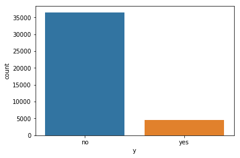

```python
#plot for class/target variable
sns.countplot(x='y',data=full_data)
```

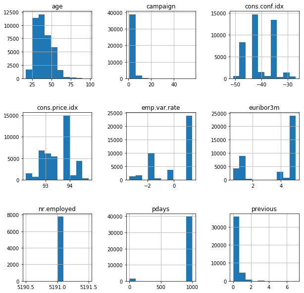

```python
#visualizing features of dataset
header = ['age','campaign','pdays','previous','emp.var.rate','cons.price.idx','cons.conf.idx','euribor3m','nr.employed']
full_data.hist(column=header,figsize=(10,10))
plt.subplots_adjust(wspace = 0.5, hspace = 0.5)
plt.show()
```

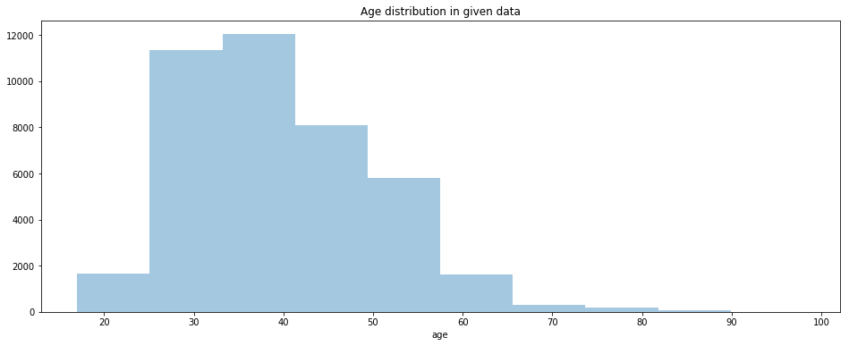

```python
#histogram - to visualize age feature - with different dimensions
h = sns.distplot(full_data['age'], bins=10, kde=False)
plt.title('Age distribution in given data')
h.figure.set_size_inches(16,6)
```

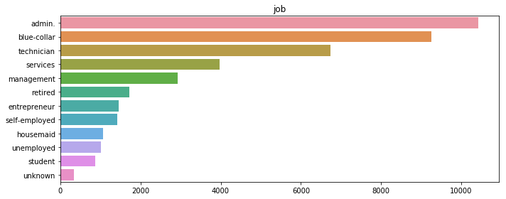

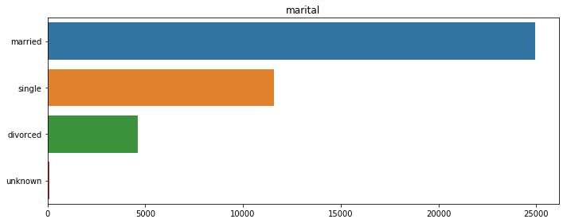

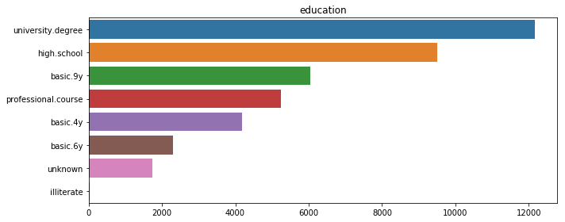

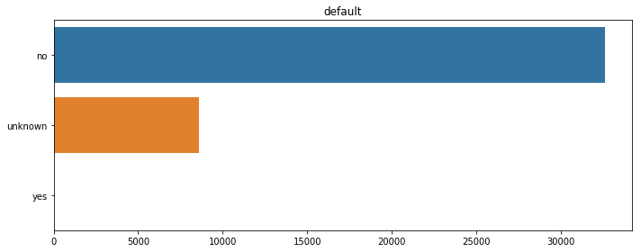

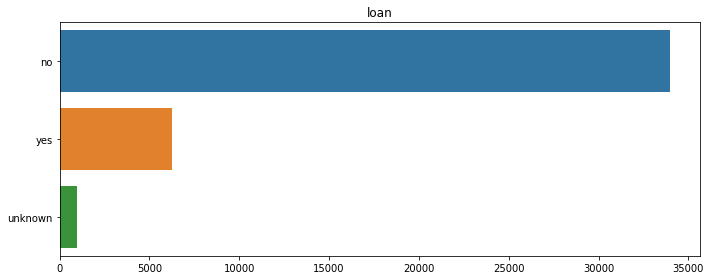

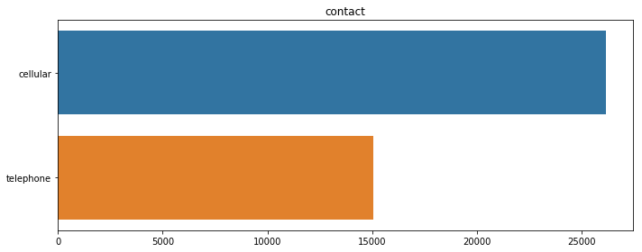

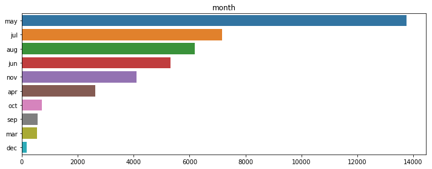

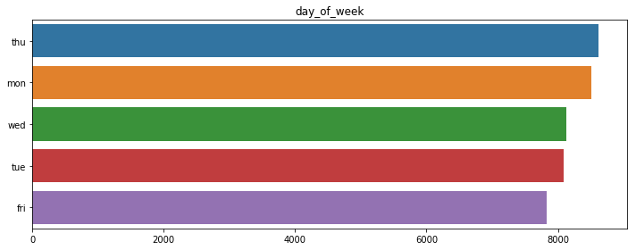

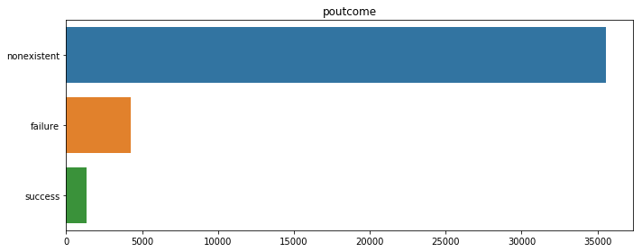

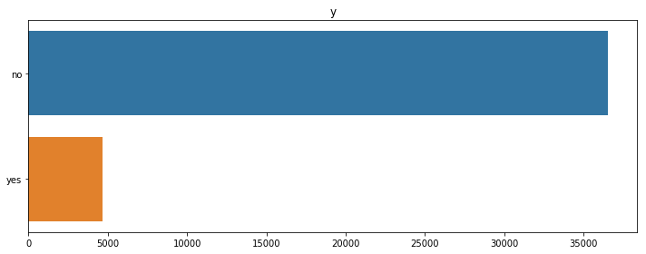

```python
#bar graphs for all features - values
categorcial_variables = ['job', 'marital', 'education', 'default', 'loan', 'contact', 'month', 'day_of_week', 'poutcome','y']
for col in categorcial_variables:
    plt.figure(figsize=(10,4))
    sns.barplot(full_data[col].value_counts().values, full_data[col].value_counts().index)
    plt.title(col)
    plt.tight_layout()
```

### Some more detailed analysis - Comparing one feature with other

```python
def cross_tab(full_data,f1,f2):
    jobs=list(full_data[f1].unique())
    edu=list(full_data[f2].unique())
    dataframes=[]
    for e in edu:
        dfe=full_data[full_data[f2]==e]
        dfejob=dfe.groupby(f1).count()[f2]
        dataframes.append(dfejob)
    xx=pd.concat(dataframes,axis=1)
    xx.columns=edu
    xx=xx.fillna(0)
    return xx

cross_tab(full_data,'job','education')
```

|  | basic.4y | high.school | basic.6y | basic.9y | professional.course | unknown | university.degree | illiterate |
| --- | --- | --- | --- | --- | --- | --- | --- | --- |
| admin. | 77 | 3329 | 151 | 499 | 363 | 249 | 5753 | 1.0 |
| blue-collar | 2318 | 878 | 1426 | 3623 | 453 | 454 | 94 | 8.0 |
| entrepreneur | 137 | 234 | 71 | 210 | 135 | 57 | 610 | 2.0 |
| housemaid | 474 | 174 | 77 | 94 | 59 | 42 | 139 | 1.0 |
| management | 100 | 298 | 85 | 166 | 89 | 123 | 2063 | 0.0 |
| retired | 597 | 276 | 75 | 145 | 241 | 98 | 285 | 3.0 |
| self-employed | 93 | 118 | 25 | 220 | 168 | 29 | 765 | 3.0 |
| services | 132 | 2682 | 226 | 388 | 218 | 150 | 173 | 0.0 |
| student | 26 | 357 | 13 | 99 | 43 | 167 | 170 | 0.0 |
| technician | 58 | 873 | 87 | 384 | 3320 | 212 | 1809 | 0.0 |
| unemployed | 112 | 259 | 34 | 186 | 142 | 19 | 262 | 0.0 |
| unknown | 52 | 37 | 22 | 31 | 12 | 131 | 45 | 0.0 |

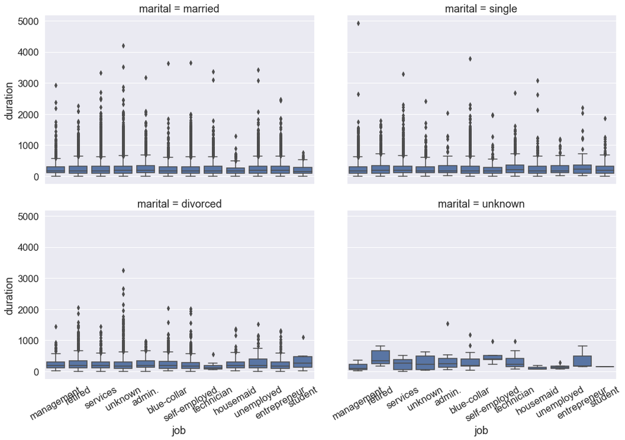

```python
sns.set(font_scale=1.5)
g = sns.FacetGrid(full_data, col="marital", col_wrap=2, size=5, aspect=1.5)
g.map(sns.boxplot, "job","duration").set_xticklabels(rotation=30)
```

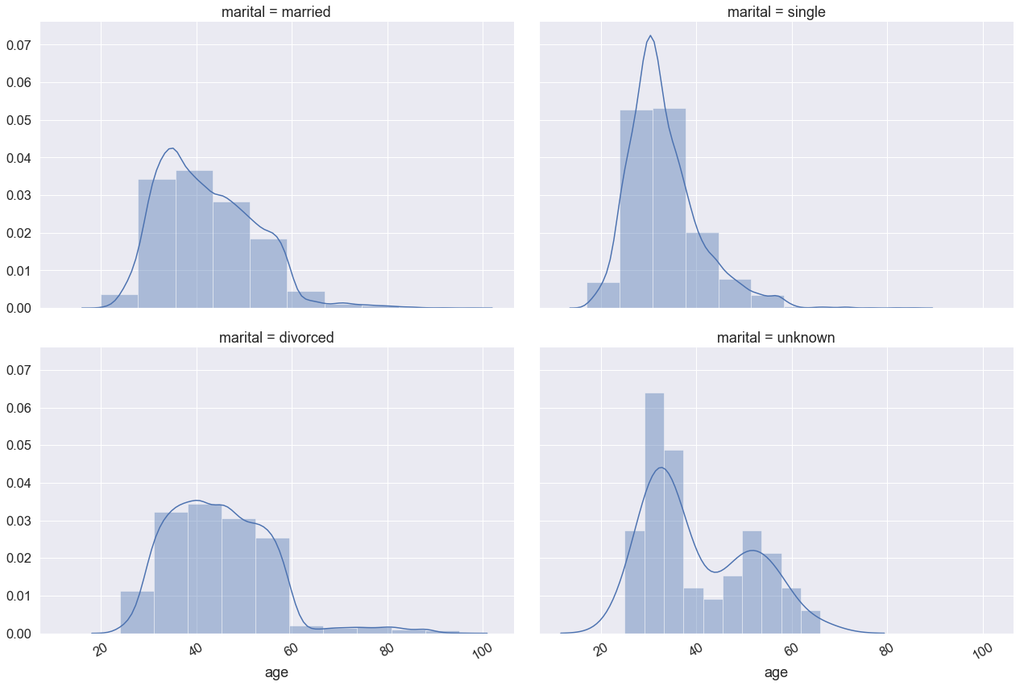

```python
sns.set(font_scale=1.5)
g = sns.FacetGrid(full_data, col="marital", col_wrap=2, size=6, aspect=1.5)
g.map(sns.distplot, "age", bins=10).set_xticklabels(rotation=30)
```

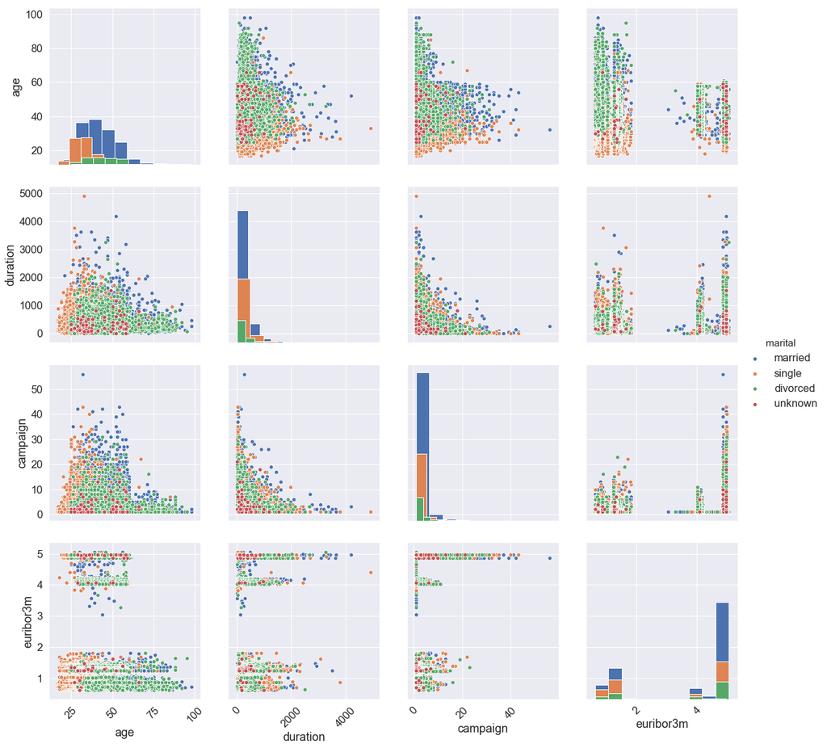

```python
#'emp.var.rate', 'cons.price.idx', 'cons.conf.idx', 'euribor3m', 'nr.employed'
sns.set(font_scale=1.5)
g = sns.pairplot(full_data[["age", "duration", "marital", "campaign","euribor3m"]], hue="marital", diag_kind="hist", size=4)
for ax in g.axes.flat:
    plt.setp(ax.get_xticklabels(), rotation=45)
```

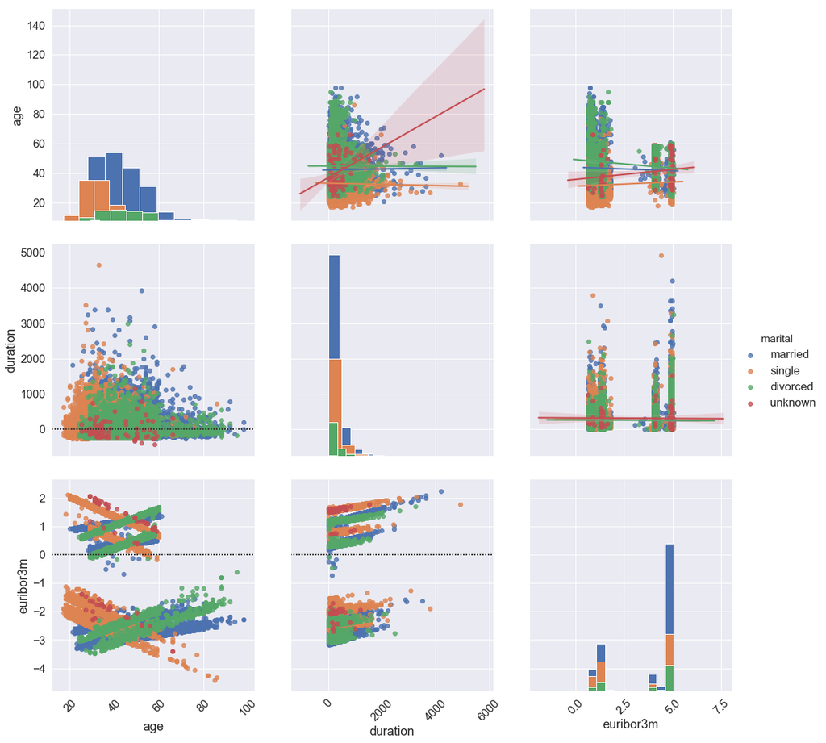

```python
sns.set(font_scale=1.5)
g = sns.PairGrid(full_data[["age", "duration", "marital", "euribor3m"]], hue="marital", size=5)
g.map_upper(sns.regplot)
g.map_lower(sns.residplot)
g.map_diag(plt.hist)
for ax in g.axes.flat:
    plt.setp(ax.get_xticklabels(), rotation=45)
g.add_legend()
g.set(alpha=0.5)
```

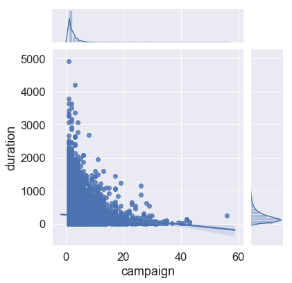

```python
sns.set(font_scale=1.5)
g = sns.JointGrid(x="campaign", y="duration", data=full_data, size=6)
g.plot_joint(sns.regplot, order=2)
g.plot_marginals(sns.distplot)
```

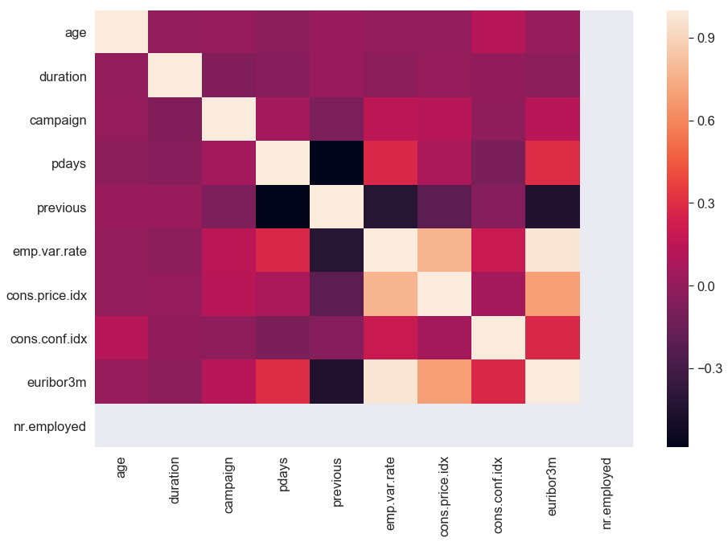

```python
# visualize correlations of features with a heatmap
plt.figure(figsize=(15, 10))
sns.heatmap(full_data.corr())
plt.xticks(rotation=90)
plt.yticks(rotation=0)
```

## 3. Data Preprocessing/Cleaning

I will prepare the data by splitting feature and target/label columns and also check for quality of given data and perform data cleaning. To check if the model, which I created is good, I will split the data into training and validation sets to check the accuracy of the best model. I will split the given data into two sets,70% of which will be used to train our models and 30% will be used as a validation/test set.

### 3.1 Preprocess Feature Columns

As you can see, there are several non-numeric columns that need to be converted! Many of them are simply yes/no, e.g. housing. These can be reasonably converted into 1/0 (binary) values. Other columns, like profession and marital, have more than two values, and are known as categorical variables. The recommended way to handle such a column is to create as many columns as possible values (e.g. profession_admin, profession_blue-collar, etc.), and assign a 1 to one of them and 0 to all others. These generated columns are sometimes called dummy variables, and we will use the pandas.get_dummies() function to perform this transformation. The code cell below performs the preprocessing routine.

```python
def preprocess_features(X):
    ''' Preprocesses the student data and converts non-numeric binary variables into
        binary (0/1) variables. Converts categorical variables into dummy variables. '''

    # Initialize new output DataFrame
    output = pd.DataFrame(index = X.index)

    # Investigate each feature column for the data
    for col, col_data in X.iteritems():

        # If data type is non-numeric, replace all yes/no values with 1/0
        if col_data.dtype == object:
            col_data = col_data.replace(['yes', 'no','unknown'], [1, 0, np.nan])

        # If data type is categorical, convert to dummy variables
        if col_data.dtype == object:
            col_data = pd.get_dummies(col_data, prefix = col)

        # Collect the revised columns
        output = output.join(col_data)

    return output

full_data = preprocess_features(full_data)
print("Processed feature columns ({} total features):\n{}".format(len(full_data.columns), list(full_data.columns)))
```

```
Processed feature columns (55 total features):
['age', 'job_admin.', 'job_blue-collar', 'job_entrepreneur', 'job_housemaid', 'job_management', 'job_retired', 'job_self-employed', 'job_services', 'job_student', 'job_technician', 'job_unemployed', 'marital_divorced', 'marital_married', 'marital_single', 'education_basic.4y', 'education_basic.6y', …
```

### 3.2 Identify feature and target columns

```python
# Extract feature columns
feature_cols = list(full_data.columns[:-1])

# Extract target column 'responded'
target_col = full_data.columns[-1]

# Show the list of columns
print("Feature columns:\n{}".format(feature_cols))
print("\nTarget column: {}".format(target_col))

# Separate the data into feature data and target data (X_all and y_all, respectively)
X_all = full_data[feature_cols]
y_all = full_data[target_col]

# Show the feature information by printing the first five rows
print("\nFeature values:")
print(X_all.head())
```

```
Feature columns:
['age', 'job_admin.', 'job_blue-collar', 'job_entrepreneur', 'job_housemaid', 'job_management', 'job_retired', 'job_self-employed', 'job_services', 'job_student', 'job_technician', 'job_unemployed', 'marital_divorced', 'marital_married', 'marital_single', 'education_basic.4y', 'education_basic.6y', …

Target column: y

Feature values:
   age  job_admin.  job_blue-collar  job_entrepreneur  job_housemaid  \
0   56           0                0                 0              1
1   57           0                0                 0              0
2   37           0                0                 0              0
3   40           1                0                 0              0
4   56           0                0                 0              0

   job_management  job_retired  job_self-employed  job_services  job_student  \
0               0            0                  0             0            0
1               0            0                  0             1            0
2               0            0                  0             1            0
3               0            0                  0             0            0
4               0            0                  0             1            0

      ...       pdays  previous  poutcome_failure  poutcome_nonexistent  \
0     ...         999         0                 0                     1
1     ...         999         0                 0                     1
2     ...         999         0                 0                     1
3     ...         999         0                 0                     1
4     ...         999         0                 0                     1

   poutcome_success  emp.var.rate  cons.price.idx  cons.conf.idx  euribor3m  \
0                 0           1.1          93.994          -36.4      4.857
1                 0           1.1          93.994          -36.4      4.857
2                 0           1.1          93.994          -36.4      4.857
3                 0           1.1          93.994          -36.4      4.857
4                 0           1.1          93.994          -36.4      4.857

   nr.employed
0       5191.0
1       5191.0
2       5191.0
3       5191.0
4       5191.0

[5 rows x 54 columns]
```

### 3.3 Data cleaning

```python
#checking for no. of missing values in each column
X_all.isnull().sum()
```

```
age                                  0
job_admin.                           0
job_blue-collar                      0
job_entrepreneur                     0
job_housemaid                        0
job_management                       0
job_retired                          0
job_self-employed                    0
job_services                         0
job_student                          0
job_technician                       0
job_unemployed                       0
marital_divorced                     0
marital_married                      0
marital_single                       0
education_basic.4y                   0
education_basic.6y                   0
education_basic.9y                   0
education_high.school                0
education_illiterate                 0
education_professional.course        0
education_university.degree          0
default                           8597
housing                            990
loan                               990
contact_cellular                     0
contact_telephone                    0
month_apr                            0
month_aug                            0
month_dec                            0
month_jul                            0
month_jun                            0
month_mar                            0
month_may                            0
month_nov                            0
month_oct                            0
month_sep                            0
day_of_week_fri                      0
day_of_week_mon                      0
day_of_week_thu                      0
day_of_week_tue                      0
day_of_week_wed                      0
duration                             0
campaign                             0
pdays                                0
previous                             0
poutcome_failure                     0
poutcome_nonexistent                 0
poutcome_success                     0
emp.var.rate                         0
cons.price.idx                       0
cons.conf.idx                        0
euribor3m                            0
nr.employed                      33425
dtype: int64
```

So looks like we have 4 columns that have missing values.

```python
#before dropping nr.employed column
print(X_all.columns)
```

```
Index(['age', 'job_admin.', 'job_blue-collar', 'job_entrepreneur',
       'job_housemaid', 'job_management', 'job_retired', 'job_self-employed',
       'job_services', 'job_student', 'job_technician', 'job_unemployed',
       'marital_divorced', 'marital_married', 'marital_single',
       'education_basic.4y', 'education_basic.6y', 'education_basic.9y',
       'education_high.school', 'education_illiterate',
       'education_professional.course', 'education_university.degree',
       'default', 'housing', 'loan', 'contact_cellular', 'contact_telephone',
       'month_apr', 'month_aug', 'month_dec', 'month_jul', 'month_jun',
       'month_mar', 'month_may', 'month_nov', 'month_oct', 'month_sep',
       'day_of_week_fri', 'day_of_week_mon', 'day_of_week_thu',
       'day_of_week_tue', 'day_of_week_wed', 'duration', 'campaign', 'pdays',
       'previous', 'poutcome_failure', 'poutcome_nonexistent',
       'poutcome_success', 'emp.var.rate', 'cons.price.idx', 'cons.conf.idx',
       'euribor3m', 'nr.employed'],
      dtype='object')
```

```python
X_all.drop('nr.employed',  axis=1, inplace=True)
```

```python
print(X_all.columns)
```

```
Index(['age', 'job_admin.', 'job_blue-collar', 'job_entrepreneur',
       'job_housemaid', 'job_management', 'job_retired', 'job_self-employed',
       'job_services', 'job_student', 'job_technician', 'job_unemployed',
       'marital_divorced', 'marital_married', 'marital_single',
       'education_basic.4y', 'education_basic.6y', 'education_basic.9y',
       'education_high.school', 'education_illiterate',
       'education_professional.course', 'education_university.degree',
       'default', 'housing', 'loan', 'contact_cellular', 'contact_telephone',
       'month_apr', 'month_aug', 'month_dec', 'month_jul', 'month_jun',
       'month_mar', 'month_may', 'month_nov', 'month_oct', 'month_sep',
       'day_of_week_fri', 'day_of_week_mon', 'day_of_week_thu',
       'day_of_week_tue', 'day_of_week_wed', 'duration', 'campaign', 'pdays',
       'previous', 'poutcome_failure', 'poutcome_nonexistent',
       'poutcome_success', 'emp.var.rate', 'cons.price.idx', 'cons.conf.idx',
       'euribor3m'],
      dtype='object')
```

```python
X_all.fillna(X_all.median(), inplace=True)
X_all.describe()
```

|  | age | job_admin. | job_blue-collar | job_entrepreneur | job_housemaid | job_management | job_retired | job_self-employed | job_services | job_student | ... | campaign | pdays | previous | poutcome_failure | poutcome_nonexistent | poutcome_success | emp.var.rate | cons.price.idx | cons.conf.idx | euribor3m |
| --- | --- | --- | --- | --- | --- | --- | --- | --- | --- | --- | --- | --- | --- | --- | --- | --- | --- | --- | --- | --- | --- |
| count | 41188.00000 | 41188.000000 | 41188.000000 | 41188.000000 | 41188.000000 | 41188.000000 | 41188.000000 | 41188.000000 | 41188.000000 | 41188.000000 | ... | 41188.000000 | 41188.000000 | 41188.000000 | 41188.000000 | 41188.000000 | 41188.000000 | 41188.000000 | 41188.000000 | 41188.000000 | 41188.000000 |
| mean | 40.02406 | 0.253035 | 0.224677 | 0.035350 | 0.025736 | 0.070992 | 0.041760 | 0.034500 | 0.096363 | 0.021244 | ... | 2.567593 | 962.475454 | 0.172963 | 0.103234 | 0.863431 | 0.033335 | 0.081886 | 93.575664 | -40.502600 | 3.621291 |
| std | 10.42125 | 0.434756 | 0.417375 | 0.184665 | 0.158348 | 0.256814 | 0.200042 | 0.182513 | 0.295092 | 0.144199 | ... | 2.770014 | 186.910907 | 0.494901 | 0.304268 | 0.343396 | 0.179512 | 1.570960 | 0.578840 | 4.628198 | 1.734447 |
| min | 17.00000 | 0.000000 | 0.000000 | 0.000000 | 0.000000 | 0.000000 | 0.000000 | 0.000000 | 0.000000 | 0.000000 | ... | 1.000000 | 0.000000 | 0.000000 | 0.000000 | 0.000000 | 0.000000 | -3.400000 | 92.201000 | -50.800000 | 0.634000 |
| 25% | 32.00000 | 0.000000 | 0.000000 | 0.000000 | 0.000000 | 0.000000 | 0.000000 | 0.000000 | 0.000000 | 0.000000 | ... | 1.000000 | 999.000000 | 0.000000 | 0.000000 | 1.000000 | 0.000000 | -1.800000 | 93.075000 | -42.700000 | 1.344000 |
| 50% | 38.00000 | 0.000000 | 0.000000 | 0.000000 | 0.000000 | 0.000000 | 0.000000 | 0.000000 | 0.000000 | 0.000000 | ... | 2.000000 | 999.000000 | 0.000000 | 0.000000 | 1.000000 | 0.000000 | 1.100000 | 93.749000 | -41.800000 | 4.857000 |
| 75% | 47.00000 | 1.000000 | 0.000000 | 0.000000 | 0.000000 | 0.000000 | 0.000000 | 0.000000 | 0.000000 | 0.000000 | ... | 3.000000 | 999.000000 | 0.000000 | 0.000000 | 1.000000 | 0.000000 | 1.400000 | 93.994000 | -36.400000 | 4.961000 |
| max | 98.00000 | 1.000000 | 1.000000 | 1.000000 | 1.000000 | 1.000000 | 1.000000 | 1.000000 | 1.000000 | 1.000000 | ... | 56.000000 | 999.000000 | 7.000000 | 1.000000 | 1.000000 | 1.000000 | 1.400000 | 94.767000 | -26.900000 | 5.045000 |

8 rows × 53 columns

```python
print("Processed feature columns ({} total features):\n{}".format(len(X_all.columns), list(X_all.columns)))
```

```
Processed feature columns (53 total features):
['age', 'job_admin.', 'job_blue-collar', 'job_entrepreneur', 'job_housemaid', 'job_management', 'job_retired', 'job_self-employed', 'job_services', 'job_student', 'job_technician', 'job_unemployed', 'marital_divorced', 'marital_married', 'marital_single', 'education_basic.4y', 'education_basic.6y', …
```

```python
# Export cleaned data

filename = 'cleaned_X_all.csv'
X_all.to_csv(filename, index=False, encoding='utf-8')
filename = 'cleaned_y_all.csv'
y_all.to_csv(filename, index=False, encoding='utf-8')
```

```python
# Read cleaned data directly
import numpy as np
import pandas as pd
from pandas import Series
import seaborn as sns
from pandas.plotting import scatter_matrix
import matplotlib.pyplot as plt
from time import time
from IPython.display import display
from sklearn import model_selection
from sklearn.metrics import accuracy_score
from sklearn.metrics import classification_report
from sklearn.metrics import confusion_matrix
from sklearn.metrics import f1_score

%matplotlib inline

in_file = 'cleaned_X_all.csv'
X_all = pd.read_csv(in_file)
in_file = 'cleaned_y_all.csv'
y_all = pd.read_csv(in_file, squeeze=True, header=None)
```

### 3.4 Training and Validation/Test Data Split

So far, I have converted all categorical features into numeric values. For the next step, I will split the data (both features and corresponding labels) into training and test sets. In the code cell below, I will implement the following:

```python
validation_size = 0.30
from sklearn.model_selection import train_test_split

X_train, X_test, y_train, y_test = train_test_split(X_all, y_all, stratify = y_all,
                                                    test_size = validation_size, random_state = 123)
print("Train set 'yes' pct = {:.2f}%".format(100 * (y_train == 1).mean()))
print("Validation/Test set 'yes' pct = {:.2f}%".format(100 * (y_test == 1).mean()))


# Show the results of the split
print("Training set has {} samples.".format(X_train.shape[0]))
print("Validation set has {} samples.".format(X_test.shape[0]))
```

```
Train set 'yes' pct = 11.27%
Validation/Test set 'yes' pct = 11.26%
Training set has 28831 samples.
Validation set has 12357 samples.
```

## 4. Evaluate ML Algorithms - Building models

### 4.1 Logistic Regression

```
Predictions of class label:
[0 0 0 ... 0 0 0]
Accuracy of logistic regression classifier on test set: 90.69


Some detailed Analysis
Confusion Matrix :
[[10686   279]
 [  871   521]]
Accuracy Score : 90.69353402929514

Classification Report :
              precision    recall  f1-score   support

           0       0.92      0.97      0.95     10965
           1       0.65      0.37      0.48      1392

    accuracy                           0.91     12357
   macro avg       0.79      0.67      0.71     12357
weighted avg       0.89      0.91      0.90     12357
```

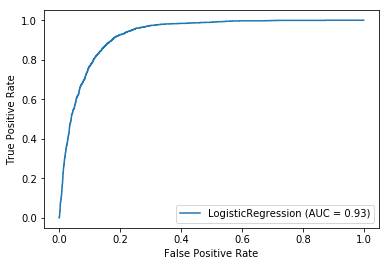

```python
from sklearn.linear_model import LogisticRegression
import matplotlib.pyplot as plt
from sklearn.metrics import plot_roc_curve
import warnings
warnings.filterwarnings('ignore')

logmodel = LogisticRegression(C=0.0008)
logmodel.fit(X_train,y_train)

predictions = logmodel.predict(X_test)
print("\nPredictions of class label:")
print(predictions)
print('Accuracy of logistic regression classifier on test set: {:.2f}'.format(logmodel.score(X_test, y_test)*100))

results = confusion_matrix(y_test,predictions)

print ('\n\nSome detailed Analysis \nConfusion Matrix :')

print(results)

print ('Accuracy Score :',accuracy_score(y_test, predictions)*100)

print('\nClassification Report : ')

print (classification_report(y_test, predictions))

plot_roc_curve(logmodel, X_test, y_test)

plotresults=[]
plotnames=[]
plotresults.append(accuracy_score(y_test, predictions))
plotnames.append('LR')
```

### 4.2 Decision Tress Claasifier

```
Predictions of class label:
[0 0 0 ... 0 1 0]
Accuracy Score Using Decision Tress classifier:
88.89698146799385


Some detailed Analysis
Confusion Matrix :
[[10257   708]
 [  664   728]]
Accuracy Score : 88.89698146799385
Classification Report :
              precision    recall  f1-score   support

           0       0.94      0.94      0.94     10965
           1       0.51      0.52      0.51      1392

    accuracy                           0.89     12357
   macro avg       0.72      0.73      0.73     12357
weighted avg       0.89      0.89      0.89     12357
```

```
<sklearn.metrics._plot.roc_curve.RocCurveDisplay at 0x1dd0b6814a8>
```

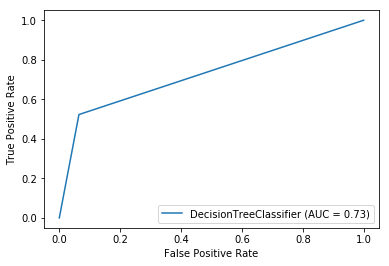

```python
from sklearn import tree
from sklearn.metrics import plot_roc_curve

clf = tree.DecisionTreeClassifier()
clf.fit(X_train,y_train)
y_pred = (clf.predict(X_test))
print("\nPredictions of class label:")
print(y_pred)
print ('Accuracy Score Using Decision Tress classifier:')
print(accuracy_score(y_test, y_pred)*100)
results = confusion_matrix(y_test,y_pred)

print ('\n\nSome detailed Analysis \nConfusion Matrix :')

print(results)

print ('Accuracy Score :',accuracy_score(y_test, y_pred)*100)

print('Classification Report : ')

print (classification_report(y_test, y_pred))

plot_roc_curve(clf, X_test, y_test)
```

### 4.3 Random Forest Classifier

It uses multiple decision trees and doesn't overfit.

```
Predictions of class label:
[0 0 0 ... 0 1 0]
Accuracy Using Random Forest Classifier: 90.87157076960428


Some detailed Analysis
Confusion Matrix :
[[10649   316]
 [  812   580]]
Accuracy Score : 90.87157076960428
Classification Report :
              precision    recall  f1-score   support

           0       0.93      0.97      0.95     10965
           1       0.65      0.42      0.51      1392

    accuracy                           0.91     12357
   macro avg       0.79      0.69      0.73     12357
weighted avg       0.90      0.91      0.90     12357
```

```
<sklearn.metrics._plot.roc_curve.RocCurveDisplay at 0x1dd0c1378d0>
```

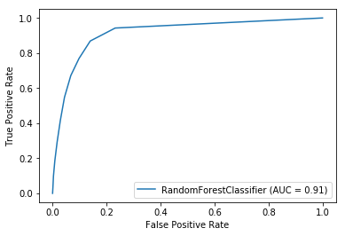

```python
#Import Random Forest Model
from sklearn.ensemble import RandomForestClassifier

#Create a Gaussian Classifier
clf=RandomForestClassifier(n_estimators=10)

#Train the model using the training sets y_pred=clf.predict(X_test)
clf.fit(X_train,y_train)

y_pred=clf.predict(X_test)


print("\nPredictions of class label:")
print(y_pred)

#Import scikit-learn metrics module for accuracy calculation
from sklearn import metrics
# Model Accuracy, how often is the classifier correct?
print("Accuracy Using Random Forest Classifier:",metrics.accuracy_score(y_test, y_pred)*100)


results = confusion_matrix(y_test,y_pred)

print ('\n\nSome detailed Analysis \nConfusion Matrix :')

print(results)

print ('Accuracy Score :',accuracy_score(y_test, y_pred)*100)

print('Classification Report : ')

print (classification_report(y_test, y_pred))

plot_roc_curve(clf, X_test, y_test)
```

### 4.4 XGBoost Classifier

```
XGBClassifier(base_score=0.5, booster='gbtree', colsample_bylevel=1,
              colsample_bynode=1, colsample_bytree=1, gamma=0, gpu_id=-1,
              importance_type='gain', interaction_constraints='',
              learning_rate=0.300000012, max_delta_step=0, max_depth=6,
              min_child_weight=1, missing=nan, monotone_constraints='()',
              n_estimators=1000, n_jobs=0, num_parallel_tree=1, random_state=0,
              reg_alpha=0, reg_lambda=1, scale_pos_weight=1, subsample=1,
              tree_method='exact', validate_parameters=1, verbosity=None)

Predictions of class label:
[1 0 0 ... 0 0 0]
Accuracy Using XG Boost Classifier: 91.04151493080846


Some detailed Analysis
Confusion Matrix :
[[10506   459]
 [  648   744]]
Accuracy Score : 91.04151493080846
Classification Report :
              precision    recall  f1-score   support

           0       0.94      0.96      0.95     10965
           1       0.62      0.53      0.57      1392

    accuracy                           0.91     12357
   macro avg       0.78      0.75      0.76     12357
weighted avg       0.91      0.91      0.91     12357
```

```
<sklearn.metrics._plot.roc_curve.RocCurveDisplay at 0x1dd0c9b4da0>
```

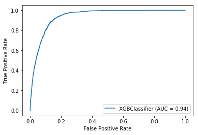

```python
import xgboost as xgb

model=xgb.XGBClassifier(n_estimators=1000)
model.fit(X_train, y_train)
print(model)

y_pred=model.predict(X_test)
print("\nPredictions of class label:")
print(y_pred)

#Import scikit-learn metrics module for accuracy calculation
from sklearn import metrics
# Model Accuracy, how often is the classifier correct?
print("Accuracy Using XG Boost Classifier:",metrics.accuracy_score(y_test, y_pred)*100)

results = confusion_matrix(y_test,y_pred)

print ('\n\nSome detailed Analysis \nConfusion Matrix :')

print(results)

print ('Accuracy Score :',accuracy_score(y_test, y_pred)*100)

print('Classification Report : ')

print (classification_report(y_test, y_pred))

plot_roc_curve(model, X_test, y_test)
```

### 4.5 Multi-layer Perceptron classifier (MLP)

```
Accuracy Score Using MLP classifier:
90.3293679695719


Some detailed Analysis
Confusion Matrix :
[[10864   101]
 [ 1094   298]]
Accuracy Score : 90.3293679695719
Classification Report :
              precision    recall  f1-score   support

           0       0.91      0.99      0.95     10965
           1       0.75      0.21      0.33      1392

    accuracy                           0.90     12357
   macro avg       0.83      0.60      0.64     12357
weighted avg       0.89      0.90      0.88     12357
```

```
<sklearn.metrics._plot.roc_curve.RocCurveDisplay at 0x192bae98be0>
```

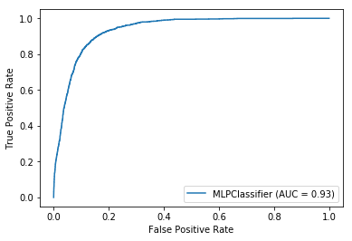

```python
from sklearn.neural_network import MLPClassifier

mlpmodel = MLPClassifier()
mlpmodel.fit(X_train, y_train)
#print('\n\n',model)

preds = mlpmodel.predict(X_test)

from sklearn.metrics import accuracy_score
# Evaluate accuracy
print ('\nAccuracy Score Using MLP classifier:')
print(accuracy_score(y_test, preds)*100)
results = confusion_matrix(y_test,preds)

print ('\n\nSome detailed Analysis \nConfusion Matrix :')

print(results)

print ('Accuracy Score :',accuracy_score(y_test, preds)*100)

print('Classification Report : ')

print (classification_report(y_test, preds))

plot_roc_curve(mlpmodel, X_test, y_test)
```

```python
import xgboost
from xgboost import XGBRFClassifier
# define the model
model = XGBRFClassifier(n_estimators=300)
model.fit(X_train, y_train)
print(model)
model.score(X_test,y_test)
```

```
XGBRFClassifier(base_score=0.5, booster='gbtree', colsample_bylevel=1,
                colsample_bytree=1, gamma=0, gpu_id=-1, importance_type='gain',
                interaction_constraints='', max_delta_step=0, max_depth=6,
                min_child_weight=1, missing=nan, monotone_constraints='()',
                n_estimators=300, n_jobs=0, num_parallel_tree=300,
                objective='binary:logistic', random_state=0, reg_alpha=0,
                scale_pos_weight=1, tree_method='exact', validate_parameters=1,
                verbosity=None)
```

```
0.9172938415473011
```

(Proposed model) -- Best model

```
Accuracy Using Stacking Classifier: 91.76984705025491


Some detailed Analysis
Confusion Matrix :
[[10640   325]
 [  692   700]]
Accuracy Score : 91.76984705025491
Classification Report :
              precision    recall  f1-score   support

           0       0.94      0.97      0.95     10965
           1       0.68      0.50      0.58      1392

    accuracy                           0.92     12357
   macro avg       0.81      0.74      0.77     12357
weighted avg       0.91      0.92      0.91     12357
```

```
<sklearn.metrics._plot.roc_curve.RocCurveDisplay at 0x192bae6fe10>
```

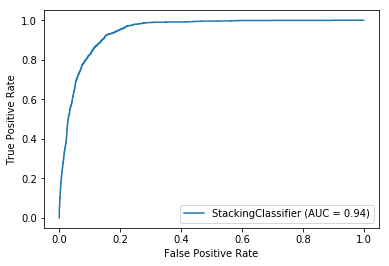

```python
import xgboost as xgb
from sklearn.ensemble import RandomForestClassifier
from sklearn.neighbors import KNeighborsClassifier
from sklearn.svm import LinearSVC
from sklearn.linear_model import LogisticRegression
from sklearn.preprocessing import StandardScaler
from sklearn.pipeline import make_pipeline
from sklearn.ensemble import StackingClassifier

estimators = [
     ('xgbrf', XGBRFClassifier(n_estimators=300)),
     ('lr', make_pipeline(StandardScaler(),
                           LogisticRegression()))
 ]

clf = StackingClassifier(
     estimators=estimators, final_estimator=LogisticRegression()
 )
clf.fit(X_train, y_train)

y_pred=clf.predict(X_test)

#Import scikit-learn metrics module for accuracy calculation
from sklearn import metrics

# Model Accuracy, how often is the classifier correct?
print("Accuracy Using Stacking Classifier:",metrics.accuracy_score(y_test, y_pred)*100)


results = confusion_matrix(y_test,y_pred)

print ('\n\nSome detailed Analysis \nConfusion Matrix :')

print(results)

print ('Accuracy Score :',accuracy_score(y_test, y_pred)*100)

print('Classification Report : ')

print (classification_report(y_test, y_pred))

plot_roc_curve(clf, X_test, y_test)
```